# Phylogenetic Comparative Methods for Paleobiology

# Choose Your Own Adventure

As we mentioned right at the beginning of the tutorial there are now **a lot** of different phylogenetic comparative approaches that can be applied to treesets to answer a diversity of questions.

If you have gotten this far, please check that your table companions are not in need of assisstance. Then investigate one of the following approaches; there is only a full working example for modelling discrete traits using `geiger` and for multi-regime models in `OUwie`, but the instructors have example code for several of the other approaches if you are interested.

## Post-hoc Modelling of Discrete Characters

If a discrete trait is inluded in the phyloegnetic inference analysis then rates and ancestral states can be jointly estimated as with other parameters. However, if you have a tree already and want to characterise a discrete trait that was not included in the inference analysis then you can use `geiger` similarly to how we used it to fit continuous traits earlier.

First fit a model with a single parameter for all transition rates

```r
ER <- fitDiscrete(tree, dat = Complexity, model = "ER")
```

Then a model where each rate is a unique parameter:

```r
ARD <- fitDiscrete(tree, dat = Complexity, model = "ARD")
```

Given that this is a multistate character, you might think (as some echinoderm workers do) that the character is ordered so that transitions can only occur between consecutive states. In this case you can use the `meristic` model

```r
MER <- fitDiscrete(tree, dat = Complexity, model = "meristic")
```

As with previous model fits we can check the AICcs to see which model fits our data better.

```r
ER[[4]]$aicc
ARD[[4]]$aicc
MER[[4]]$aicc
```

It is also straightforward to reconstruct ancestral states, this assumes an equal rates model. Phytools has useful functions for plotting the likelihood of a given state onto the tree.

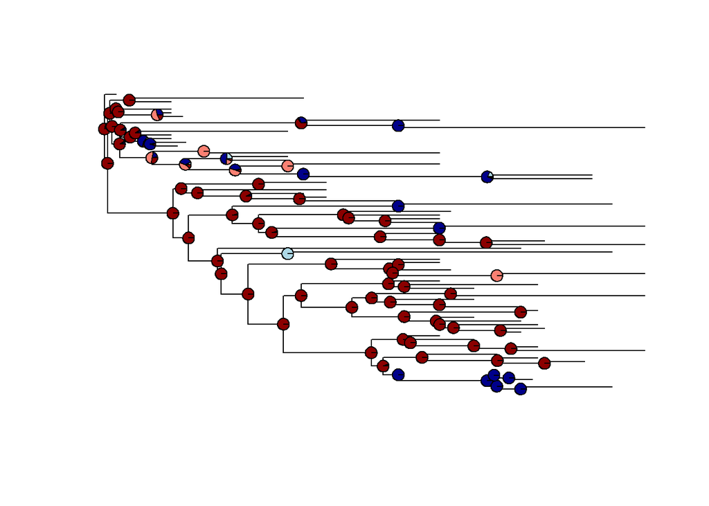

```r
anc.char <- ace(Complexity, tree, type = "discrete")
plot(ladderize(tree), show.tip.label = FALSE)
nodelabels(pie = anc.char$lik.anc,
           piecol = c("lightblue","darkblue", "salmon", "darkred"),
           cex = 0.5
           )
```

*Pie charts plotted on each node showing the likelihood the trait is in each state at that node*

## Multi-regime OU models

As we saw above, Ornstein-Uhlenbeck models have three or four parameters that define an ‘adaptive peak’. This can also be thought of as a macroevolutionary regime; for some period of time the evolution of a set of taxa can be characterised using single estimates for those parameters, and though the actual mechanisms generating the observed patterns may vary through time, they have the same outcome. This model is consistent with Simpson’s concept of the adaptive landscape. Often we would not expect that a clade would remain in the same macroevolutionary regime (i.e. where the same trait value is optimal and the strength of $\alpha$ (the constraint parameter) remains the same) over the many tens of millions of years of its evolutionary history, or that all branches of a clade would experience the same regime. We might also be interested in how the regime a clade experiences might relate to factors like environmental change.

Fortunately it is possible to model shifts in the evolutionary regime through time, by estimating new parameter values for different sections of the phylogeny. The package `OUwie` has model fitting and trait simulaiton functions for this. It requires a priori definition of clade or time regime shift points, it is therefore suitable for hypothesis testsing. See also packages `mvMorph`, `mvSLOUCH`, `OUCH` and `ape`.

`OUwie` can be used to fit models where one or more of the rate of evolution, strength of alpha or trait optimum value can change at shift points.

Multi-regime OU models can be very complex, and are therefore often difficult for the function to fit. It is **especially** important that you check the parameter values when you use this function, to make sure that they are sensible. For example if you get values for $\theta$ or $\theta$_0 that are outside the known range of trait values, or get unreasonably high values for the step rate $\sigma^{2}$. Looking to the literature for rates that might be reasonable for your trait could also help.

The following example uses the same crinoid data that we have been using previously, with possible regime shift points based on Davey’s prior knowledge as a crinoid systematist & taxonomist familiar with their morphology and ontogeny, derived from previous experience and knowledge of the published literature. When choosing possible shift points for your own trees, it will be helpful to relate them to specific hypotheses about factors that may have effected their evolutionary history (e.g. novel adaptation, dispersal to a new region, environmental change like sea level fall).

OUwie has a very specific format required for the input data. It requires a three column data frame where the first column is the taxon names, the second is the regime each tip is in (this can be overwritten later by defining a clade that has its own regime using the ‘clade =’ argument, see script below) and the third column is the trait data. You can optionally give a fourth column with the standard error of the trait measurements (this means an estimate of the intraspecific error if you have multiple specimens, plus measurement error), this is adviseable whenever it is possible. The tree must have internal node labels corresponding to the regime, again this can either be set in advance, or overwritten using the ‘clade =’ argument within the function. If set in advance you must set two or more regimes even if you are going to fit a single regime model where these will be overwritten, or you will get an error.

First set up data frame and tree correctly:

```r
shapeData <- data.frame(species = names(Shape),
                        regime = 1, shape = Shape)
densityData <- data.frame(species = names(Density),
                          regime = 1, density = Density)
#gets overwritten with correct labels later
tree$node.label <- sample(c(1,2),
                          Nnode(tree), replace = TRUE)
prunedTree$node.label <- sample(c(1,2),
                                Nnode(prunedTree), replace = TRUE)
```

`OUwie` has several options for models, you can allow the strength of the selection parameter $\alpha$ to shift, the trait optimum $\theta$, or the evolutionary rate $\sigma$, you can also fix or vary different combinations of these for each regime.

We will start by using the function to estimate brownian motion and OU parameters applied to the whole of the tree, for both shape and density, as we did previously using the `fitContinuous` function in `geiger`. As an argument in the function you must also provide the time of the root of the tree with `root.age=`, because this tree does not end at the present day. You can optionally provide starting values, often there is no problem but sometimes without them the function can have difficulty estimating parameters for the models (especially if the models do not fit the data well). This was the case here for the OU models. Ideally you would start the algorithm from a variety of values to make sure that it converges on the same parameter estimates, and not local optima. The argument `root.station` says whether the algorithm should estimate theta_0 the starting state (trait value) should be estimated as part of the model. Sometimes estimates of theta_0 and $\alpha$ can interact, setting `root.station = TRUE` means that the starting state is not estimated, this can stabilise estimates of the adaptive optimum theta. If you have reason to think there may be a trend (different starting and optimum trait means) then include theta_0 but be sure to check that the final parameter estimates are sensible. It can be sensible to check the results with both and compare.

Does `OUwie` give the same parameter estimates that the other function in `geiger` did for single regime models? What difference does specifying the error make?

```r
shapeBM <- OUwie(phy = tree, data = shapeData,
                 model = "BM1", root.station = FALSE,
                 quiet = TRUE,
                 root.age = tree$root.time)

shapeOU <- OUwie(phy = tree, data = shapeData,
                 starting.vals = c(0.01,0.01),
                 quiet = TRUE,
                 model = "OU1", root.station = FALSE,
                 root.age = tree$root.time)

densityBM <- OUwie(phy = prunedTree, data = densityData,
                   model = "BM1", root.station = FALSE,
                   quiet = TRUE,
                   root.age = tree$root.time)

densityOU <- OUwie(phy = prunedTree, data = densityData,
                   starting.vals = c(0.01,0.01),
                   quiet = TRUE,
                   model = "OU1", root.station = TRUE,
                   root.age = tree$root.time)
```

Now lets look at a multi-peak model. There are two subclades within the tree that seem to show many modifications associated with building a dense filtration fan (e.g. many branches per arm or many pinnules on branches). We can test whether this high density of the fan was associated with a different trait mean or rate of evolution. In this example we will define the tip and node regimes ourselves beforehand because it involves more than one clade. If we hypothesise a rate shift in only one clade it is easiest to use the `clade=` argument withinthe `OUwie` function.

```r
#find node defining first clade
mrca1 <- getMRCA(prunedTree, c("Blothrocrinus", "Hydreionocrinus"))

#make a vector of all descending nodes and tips
first <- c(mrca1, getDescendants(prunedTree, mrca1))
mrca2 <- getMRCA(prunedTree, c("Pirasocrinus", "Zeacrinites"))
second <- c(mrca2, getDescendants(prunedTree, mrca2))

#combine clade vectors
desc <- union(first, second)

#separate into tip and node vectors
tips <- prunedTree$tip.label[desc[desc<=Ntip(prunedTree)]]
nodes <- desc[desc>Ntip(prunedTree)]-Ntip(prunedTree)
treeD <- prunedTree
treeD$node.label <- rep(1, Nnode(treeD))
treeD$node.label[nodes] <- rep(2, length(nodes))

regimetableD <- densityData
regimetableD[tips,2] <- 2
```

We have prepared the tree and table so that they have the regimes defined appropriately for our question, now we can fit a variety of models. Here we have dropped theta_0 from the model, if you want to you can add it back in using `root.station=FALSE` to see whether it makes a difference, but remember to check for sensible parameter estimates.

```r
high_densityBMS <- OUwie(phy = treeD, data = regimetableD,
                         model = "BMS", root.station = TRUE,
                         quiet = TRUE,
                         root.age = tree$root.time)

high_densityOUM <- OUwie(phy = treeD, data = regimetableD,
                         starting.vals = c(0.01,0.01),
                         model = "OUM", root.station = TRUE,
                         quiet = TRUE,
                         root.age = tree$root.time)

high_densityOUMV <- OUwie(phy = treeD, data = regimetableD,
                          starting.vals = c(0.01,0.01),
                          model = "OUMV", root.station = TRUE,
                          quiet = TRUE,
                          root.age = tree$root.time)

high_densityOUMA <- OUwie(phy = treeD, data = regimetableD,
                          starting.vals = c(0.01,0.01),
                          model = "OUMA", root.station = TRUE,
                          quiet = TRUE,
                          root.age = tree$root.time)

#this is a complex model and may not be fit well
high_densityOUMVA <- OUwie(phy = treeD, data = regimetableD,
                           starting.vals = c(0.01,0.01),
                           model = "OUMVA", root.station = TRUE,
                           quiet = TRUE,
                           root.age = tree$root.time)
```

Now take a look at the AICcs and the parameter estimates as you did for the simple model. Which is the best fit model, and what is the AICc difference from the next best model? What are the parameter estimates and what does that suggest to us about the evolution of fan density in this group?

#### Using another trait to define regimes

If you are interested in how a particular discrete state has influenced the evolution of other traits, then you can use `OUwie` for this too. If the discrete trait is distributed over the tree rather than being confined to particular clades then you can use any ancestral state reconstruction approach to reconstruct the state at each node, and use the different states to define the regimes on the tree. For a great worked example of this approach see Sam Price’s tutorial [here](http://treethinkers.org/tutorials/state-dependent-diversification-of-traits/).

## Estimate rates on individual branches

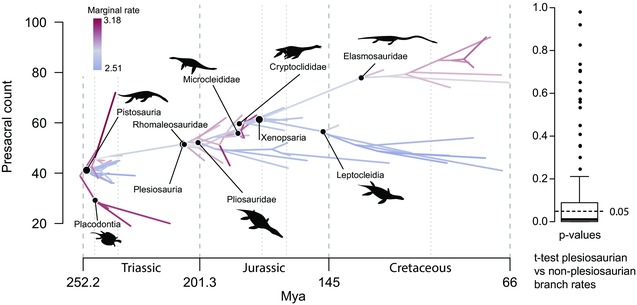

*Different rates on each branch, from Laura C. Soul and Benson (2017)*

## Multiple regimes without a priori shifts

The package `surface` can be used to estimate OU parameters jointly with regime shift points, using maximum likelihood. It tries to combine branches wherever they are on the tree to those that were experiencing attraction to the same optimum, in this way it can be thought of as a model of convergence. However, be warned, surface has been shown to be biased towards more complex models because the AIC (which is used by the shift point estimation algorithm to assess whether adding or removing new regimes provides a better fit) does not penalise additional parameters enough. It is possible to use a similar approach but substitute AIC for BIC which penalises appropriately in this scenario.

A highly flexible modelling framework was published this year by Mitov, Bartoszek, and Stadler (2019). This approach searches for shift points in regime over a phylogeny but allows and gaussian model of evolution to describe the regime, rather than just OU. The appendix of this publication compares the performance of the approach to the performance of `surface`. A tutorial and the R code to implement the approach is available on github [here](https://venelin.github.io/PCMfit).

## A general model for estimating macroevolutionary landscapes

A fairly new approach that has not yet been widely implemented (so use with caution!), particularly not for paleontological trees, is to use a Fokker-Plank-Kolmogorov (FPK) model. This is a flexible modelling framework that can be used to estimate the shape of a macroevolutionary landscape that has one or more optima, using a parameter called the ‘evolutionary potential’. This framework is distinct from the multi-peak OU models above where switches between macroevolutionary regimes are modelled; instead it fits a model of trait change in a single macroevoluionary regime, but that regime can have multiple optima, and be bounded or unbounded. When there is one peak this model is the same as an OU model. This model can be extended to define many different shapes of macroevolutionary landscape. A tutorial showing how to use R to fit the model can be found on github [here](https://github.com/fcboucher/BBMV/blob/master/Tutorial-BBMV.md).

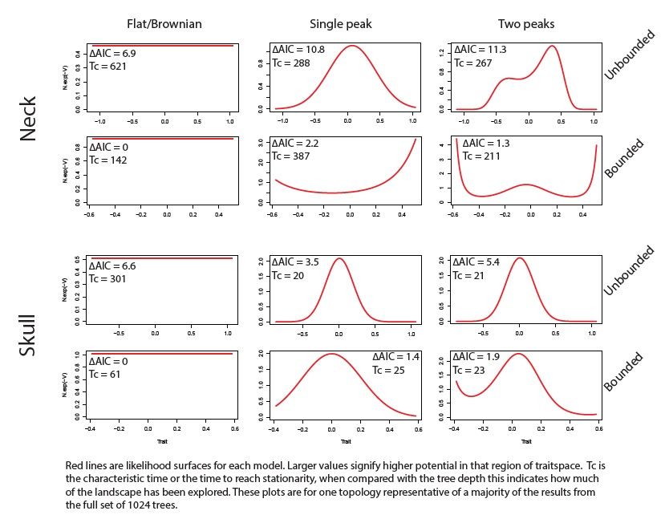

*An example of landscapes estimated with FPK*

## Some helpful introductory resources

Until relatively recently introductory explanations of PCMs were virtually non-existant. Now there are a few, and all come with online versions or supporting resources for applying the methods.

Although it is focussed on anthropology Charles Nunn’s book ‘The comparative approach in evoluionary anthropology and biology’ might be the best true introductory text, low on equations and includes excellent figures. Companion website [AnthroTree](https://wiki.duke.edu/display/AnthroTree/The+AnthroTree+Website).

Luke Harmon’s freely availiable book ‘Phylogenetic Comparative Methods’ covers all the basics then goes into a little more detail.

Modern Phylogenetic Comparative Methods and Their Application in Evolutionary Biology is comprehensive albeit expensive, and is somewhat focussed on approaches relevant to molecular trees although there is a David Bapst chapter at the very end for the paleontologists!

### References for other methods

Levy Models in Landis and Schraiber (2017) Change at speciation in Bokma (2002) and Bokma (2010) Threshold models see chapter 9 of L. J. Harmon (2019) and implementation in Liam J. Revell (2014)

# References

Bokma, Folmer. 2002. “Detection of punctuated equilibrium from molecular phylogenies.” *Journal of Evolutionary Biology* 15: 1048–56.

———. 2010. “Time, species and separating their effects on trait variance in clades.” *Systematic Biology* 59 (5): 602–7.

Felsenstein, Joseph. 1985. “Phylogenies and the comparative method.” *The American Naturalist* 125 (1): 1–15.

Gavryushkina, Alexandra, David Welch, Tanja Stadler, and Alexei Drummond. 2014. “Bayesian inference of sampled ancestor trees for epidemiology and fossil calibration.” *PLoS Computational Biology* 10 (12): e1003919. doi:10.1371/journal.pcbi.1003919.

Hansen, Thomas F. 1997. “Stabilising selection and the comparative analysis of adaptation.” *Evolution* 51 (5): 1342–51.

Harmon, Luke J. 2019. *Phylogenetic Comparative Methods*. 1.4 ed.

Heath, Tracy A, John P Huelsenbeck, and Tanja Stadler. 2014. “The fossilized birth–death process for coherent calibration of divergence-time estimates.” *Proceedings of the National Academy of Sciences* 111 (29): E2957–E2966. doi:10.1073/pnas.1319091111.

Hunt, Gene. 2012. “Measuring rates of phenotypic evolution and the inseparability of tempo and mode.” *Paleobiology* 38 (3): 351–73. doi:10.5061/dryad.c1m60s84.

Hunt, Gene, and Daniel L. Rabosky. 2014. “Phenotypic evolution in fossil species: pattern and process.” *Annual Review of Earth and Planetary Sciences* 42: 421–41. doi:10.1146/annurev-earth-040809-152524.

Landis, Michael, and Joshua G Schraiber. 2017. “Pulsed evolution shaped modern vertebrate diversity.” *Proceedings of the National Academy of Sciences of the United States of America* 114 (50): 13224–9. doi:10.1101/151175.

Louca, Stilianos, and Matthew W Pennell. 2019. “Phylogenies of extant species are consistent with an infinite array of diversification histories.” *bioRxiv*. doi:http://dx.doi.org/10.1101/719435.

Mitov, Venelin, Krzysztof Bartoszek, and Tanja Stadler. 2019. “Automatic generation of evolutionary hypotheses using mixed Gaussian phylogenetic models.” *Proceedings of the National Academy of Science* 116 (34): 16921–6.

Nunn, Charles L. 2011. *The comparative approach in evolutionary anthropology and biology*. 1st ed. Chicago: Univeristy of Chicago Press.

Nunn, Charles L., and Robert A. Barton. 2001. “Comparative methods for studying primate adaptation and allometry.” *Evolutionary Anthropology* 10 (3): 81–98. doi:10.1002/evan.1019.

Revell, L J. 2010. “Phylogenetic signal and linear regression on species data.” *Methods in Ecology and Evolution* 1 (4): 319–29. doi:10.1111/j.2041-210X.2010.00044.x.

Revell, Liam J. 2014. “Ancestral character estimation under the threshold model from quantitative genetics.” *Evolution* 68: 743–59.

Silvestro, Daniele, Anna Kostikova, Glenn Litsios, Peter B. Pearman, and Nicolas Salamin. 2015. “Measurement errors should always be incorporated in phylogenetic comparative analysis.” *Methods in Ecology and Evolution* 6 (3): 340–46. doi:10.1111/2041-210X.12337.

Slater, Graham J, Luke J Harmon, and Michael E Alfaro. 2012. “Integrating fossils with molecular phylogenies improves inference of trait evolution.” *Evolution* 66 (12): 3931–44. doi:10.5061/dryad.q96d7.

Soul, Laura C, and Matt Friedman. 2015. “Taxonomy and phylogeny can yield comparable results in comparative palaeontological analyses.” *Systematic Biology* 64 (4): 608–20.

Soul, Laura C., and Roger B J Benson. 2017. “Developmental mechanisms of macroevolutionary change in the tetrapod axis: A case study of Sauropterygia.” *Evolution* 71 (5): 1164–77. doi:10.1111/evo.13217.

Wright, David F. 2017. “Phenotypic Innovation and Adaptive Constraints in the Evolutionary Radiation of Palaeozoic Crinoids.” *Scientific Reports* 7 (1). Springer US: 1–10. doi:10.1038/s41598-017-13979-9.